# `tidyplots`: Data Visualisation Made Simple(R)

[figure not shown]

Associate Professor Dr. Jason Ng

# 1 What is `tidyplots?`

## 1.1 Introduction

- `tidyplots` is an R package to generate publication-ready plots for scientific papers.
- Created by Jan Broder Engler. Refer to [Engler (2025)](https://onlinelibrary.wiley.com/doi/10.1002/imt2.70018).
- Goal is to streamline the creation of such publication-ready plots by using a consistent and intuitive syntax that allows you to gradually add, remove and adjust plot components.
- Engler (2025) recognises that although `ggplot2` has its *“utility and power, each of these tools uses a specialized syntax and requires significant coding experience, posing a barrier to adoption by .. scientists”*. He further adds, “*Something as simple as a scatter plot with error bars and a statistical test typically requires a considerable amount of code and intricate knowledge of the plotting tool’s internal workings*”.

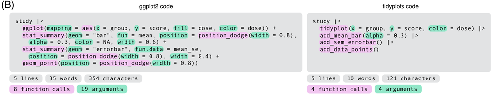

Source: Engler (2025)

- Hence, `tidyplots` empowers researchers to leverage automated data visualisation pipelines while minimising required programming skills.

## 1.2 Some examples

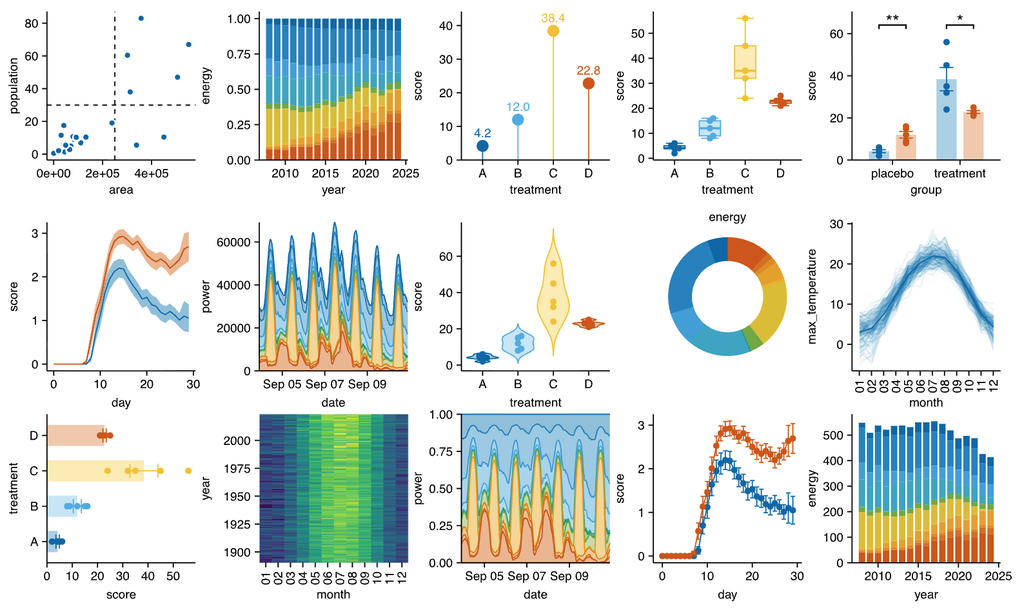

Source: Engler (2025)

# 2 `tidyplots` syntax

## 2.1 Workflow Overview

[figure not shown]

Source: Engler (2025)

## 2.2 Verbs in `tidyplots`

- The tidyplots workflow is composed of a series of function calls connected in one pipeline.
- After starting the plot using the `tidyplot()` function, there are three main verbs to construct and modify the plot:
  1. add
  2. remove
  3. adjust
- User can also have the option to choose a different theme (equivalent to `ggplot2`’s `gg_theme`), split the plot into a multiplot layout (equivalent to `ggplot2`s `facet_grid`) or save it to file.
- The following cheatsheet you a quick overview of the verbs and their associated options. (Click image to enlarge).

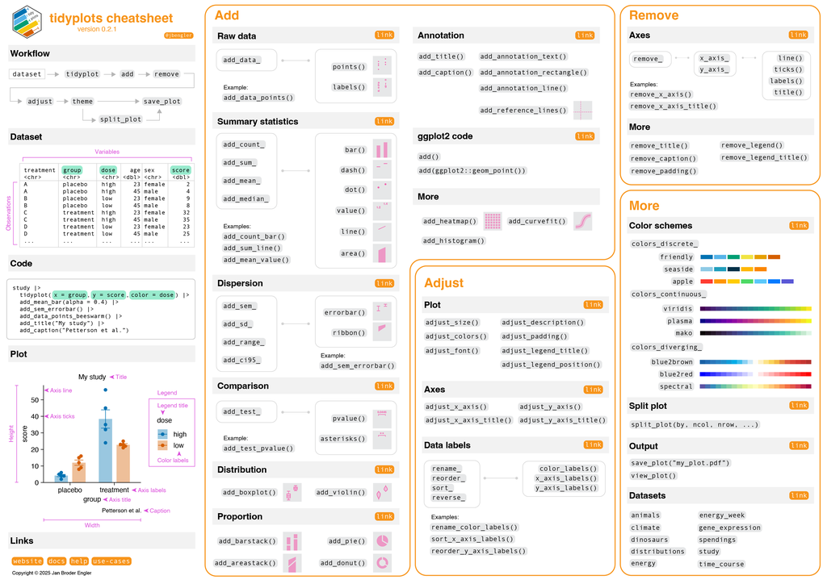

## 2.3 An Example

- We’ll use the `study` data set from the `tidyplots` package and follow the example from Engler (2025) to demonstrate the use of `tidyplots`.
- The `study` data set includes a treatment and placebo group at two different treatment doses and a score measuring treatment success.

```r
library(tidyplots)

head(study)
```

```
# A tibble: 6 × 7
  treatment group   dose  participant   age sex    score
  <chr>     <chr>   <chr> <chr>       <dbl> <chr>  <dbl>
1 A         placebo high  p01            23 female     2
2 A         placebo high  p02            45 male       4
3 A         placebo high  p03            32 female     5
4 A         placebo high  p04            37 male       4
5 A         placebo high  p05            24 female     6
6 B         placebo low   p06            23 female     9
```

- We’ll define x-axis to be `group`, y-axis to be `score` and colour by `dose`.

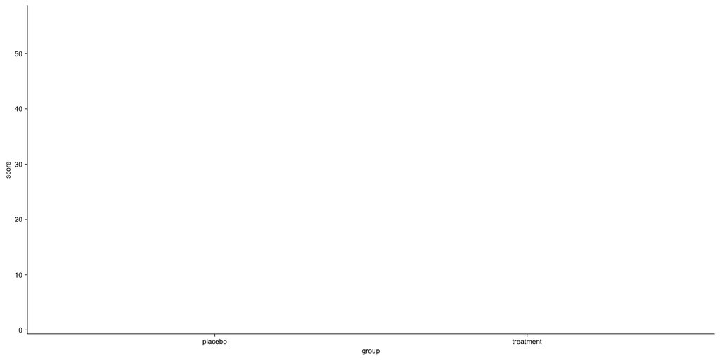

```r
study %>%
  tidyplot(x = group, y = score, colour = dose)
```

- Next, we *add* the *mean* value of each group represented as a *bar* using the `add_mean_bar()` function. Unlike the `ggplot2` function where we use the `+` operator, we continue to use the `%>%` or `|>` operator.

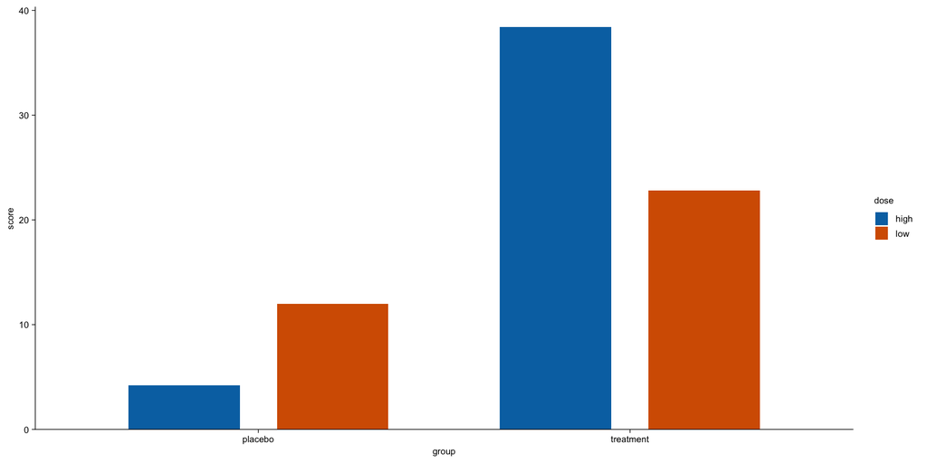

```r
study %>%
  tidyplot(x = group, y = score, colour = dose) %>%
  add_mean_bar()
```

- This exemplifies the general scheme in which the function names
  1. start with an action verb (e.g. add),
  2. followed by the statistical entity (e.g. mean),
  3. followed by the graphical representation of the entity (e.g. bar)
- To add the standard error of the mean (sem) as an error bar, we use the function `add_sem_errorbar`:

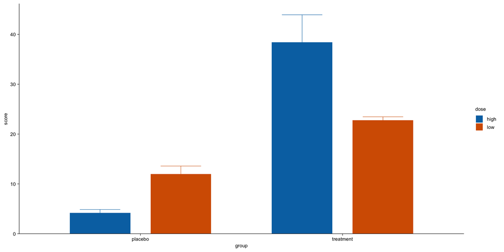

```r
study %>%
  tidyplot(x = group, y = score, colour = dose) %>%
  add_mean_bar() %>%
  add_sem_errorbar()
```

- We’ll continue to add the data as data points, and also add a statistical test as *p* values (we’ll also change the opacity of the barchart by using the `alpha` argument:

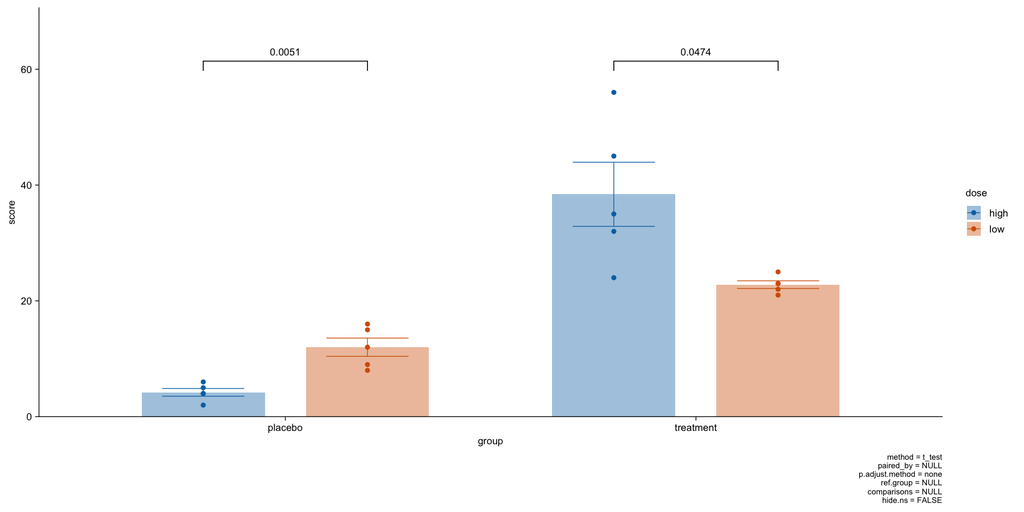

```r
study %>%
  tidyplot(x = group, y = score, colour = dose) %>%
  add_mean_bar(alpha = 0.4) %>%
  add_sem_errorbar() %>%
  add_data_points() %>%
  add_test_pvalue()
```

- In the next step, the user can remove unwanted plot elements and adjust the appearance of the plot, including colours, font, legend, titles, size, padding and axes. For example,

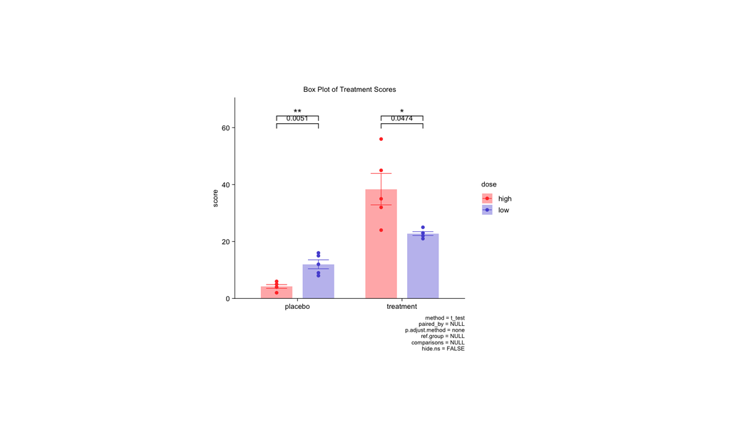

```r
study %>%
  tidyplot(x = group, y = score, colour = dose) %>%
  add_mean_bar(alpha = 0.4) %>%
  add_sem_errorbar() %>%
  add_data_points() %>%
  add_test_pvalue() %>%
  add_test_asterisks(hide_info = T) %>%
  add_title(title = "Box Plot of Treatment Scores") %>%
  remove_x_axis_title() %>%
  adjust_size(width = 80, height = 70) %>%
  adjust_colors(colors_discrete_apple)
```

# 3 Case Study (Time Series): COVID-19 in Malaysia

## 3.1 Data Preparation

- We’ll directly import the daily COVID-19 data for each state and Federal Territory from the [Ministry of Health’s Github](https://github.com/MoH-Malaysia/covid19-public) page.
- Next, we prepare our data by converting the daily cases into monthly cases.

```r
covid <- read_csv(
  "https://raw.githubusercontent.com/MoH-Malaysia/covid19-public/refs/heads/main/epidemic/cases_state.csv"
  )

covid <- covid %>%
  mutate(year = year(date),
         month = month(date, label = TRUE))

covid_monthly <- covid %>%
  group_by(state, year, month) %>%
  summarise(cases_new_state = sum(cases_new)) %>%
  mutate(date = make_date(year, month))

view(covid_monthly)
```

## 3.2 Line Chart

- We compare the `ggplot2` and `tidyplots` codes used to plot (i) all-in-one plot and (ii) multiple plots in one.
- The associated functions to plot a line chart are `geom_line` and `add_line()` in the `ggplot2` and `tidyplots` library packages, respectively.

**All-in-one plot**

```r
# ggplot2
covid_monthly %>%
  ggplot(aes(x = date, y = cases_new_state, col = state)) +
  geom_line()

# tidyplots
covid_monthly %>%
  tidyplot(x = date, y = cases_new_state, color = state) %>%
  add_line()
```

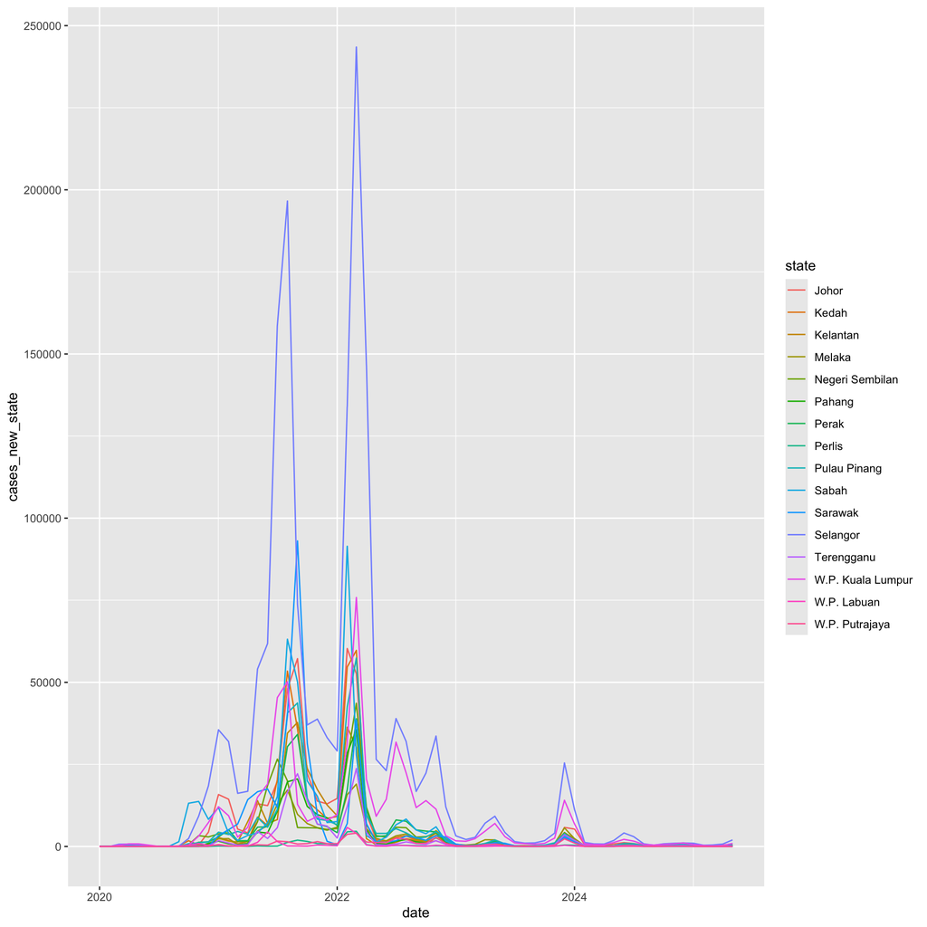

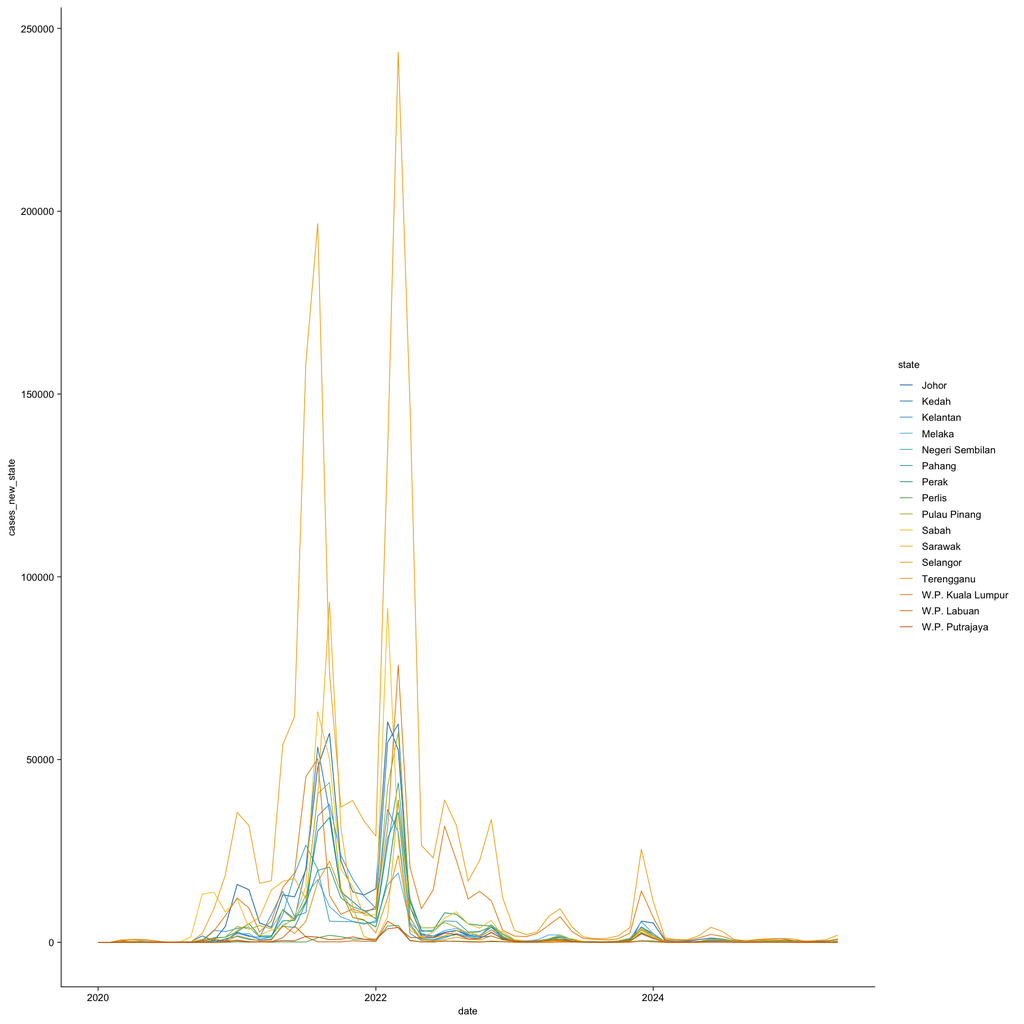

**Multiple plots in one**

```r
# ggplot2
covid_monthly %>%
  ggplot(aes(x = date, y = cases_new_state)) +
  geom_line() +
  facet_wrap(~state, nrow = 4, scales = "free")

# tidyplots
covid_monthly %>%
  tidyplot(x = date, y = cases_new_state) %>%
  add_line() %>%
  split_plot(by = state, nrow = 4)
```

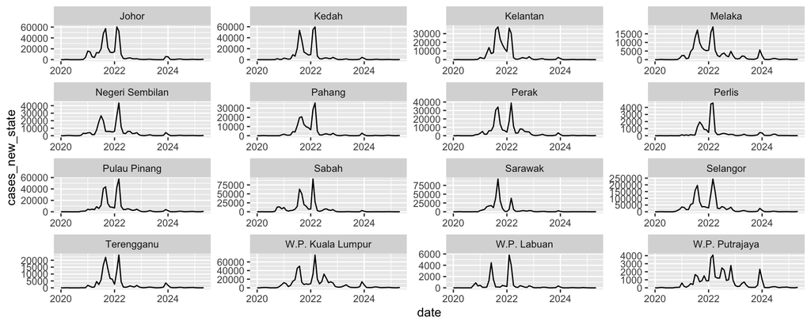

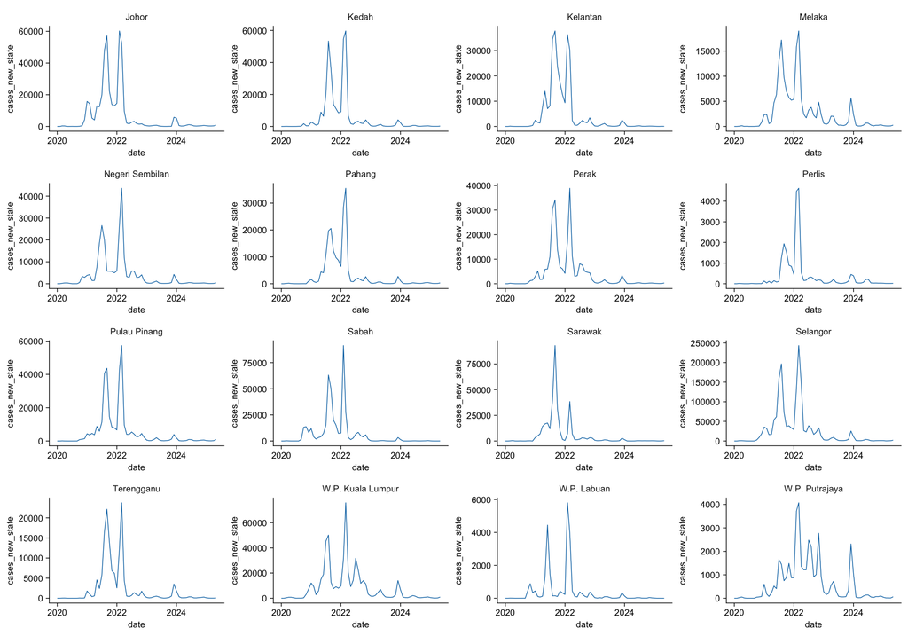

## 3.3 Stacked Area Chart

- A stacked area chart is essentially an area chart with multiple categories “stacked” on top of each other, representing either absolute counts or relative proportion values.
- Lets compare the proportion of COVID-19 infections for each state across the years. The associated functions are `geom_area` and `add_areastack_relative()` in the `ggplot2` and `tidyplots` library packages, respectively.

```r
#ggplot2
covid_monthly %>%
  ggplot(aes(x = date, y = cases_new_state, fill = state)) +
  geom_area(position = "fill")

#tidyplots
covid_monthly %>%
  tidyplot(x = date, y = cases_new_state, fill = state) %>%
  add_areastack_relative()
```

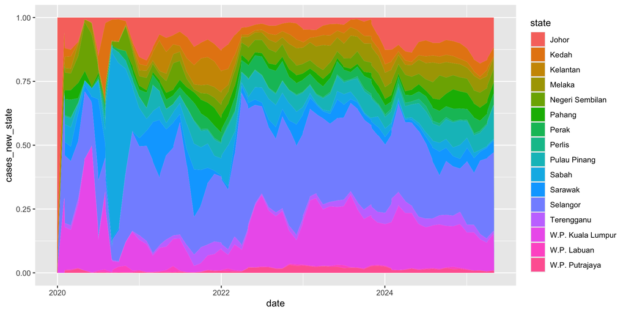

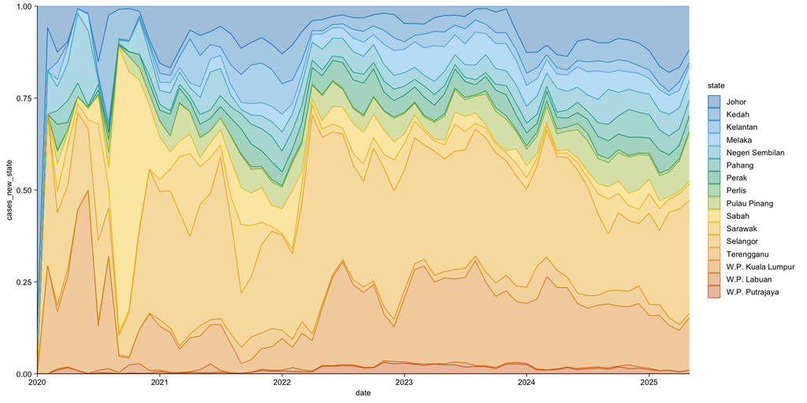

- To the `tidyplot` graph, we’ll:
  - change the color of the areas (i.e., states),
  - split them into yearly multiple plots,
  - update the y-axis title

```r
covid_monthly %>%
  tidyplot(x = date, y = cases_new_state, fill = state) %>%
  add_areastack_relative() %>%
  adjust_colors(colors_discrete_apple) %>%
  split_plot(by = year) %>%
  adjust_y_axis_title(title = "Proportion of COVID-19 Cases")
```

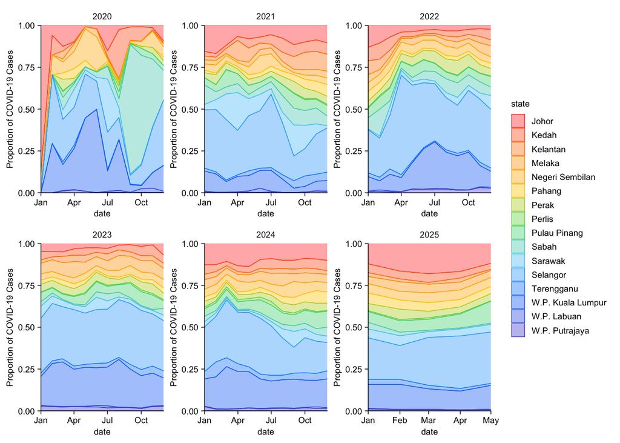

## 3.4 Heatmap

```r
covid_monthly %>%
  filter(year < 2025) %>%
  tidyplot(x = year, y = month, fill = cases_new_state) %>%
  add_heatmap() %>%
  split_plot(by = state) %>%
  adjust_colors(labels = scales::label_comma())
```

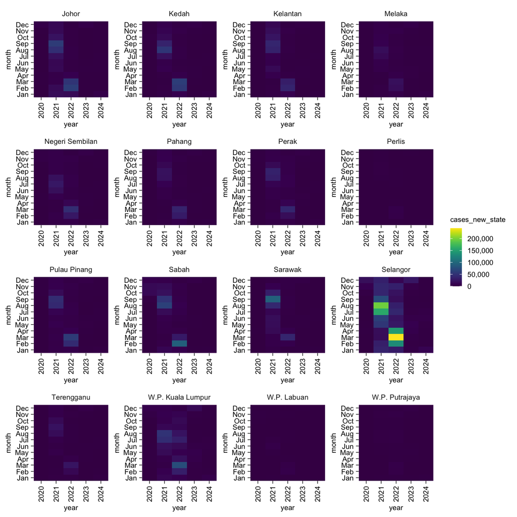

- The equivalent code of doing this using the `ggplot2` package is:

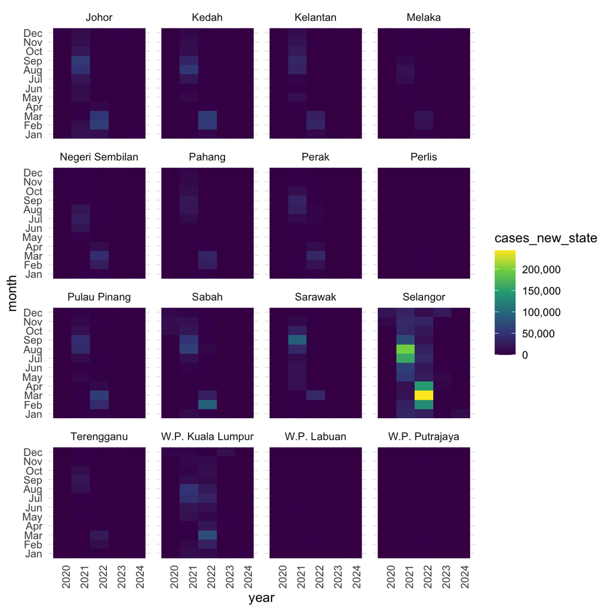

```r
covid_monthly %>%
  filter(year < 2025) %>%
  ggplot(aes(x = year, y = month, fill = cases_new_state)) +
  geom_tile() +
  facet_wrap(~state, nrow = 4) +
  scale_fill_viridis_c(labels = scales::label_comma()) +
  theme_minimal() +
  theme(axis.text.x = element_text(angle = 90))
```

- Compared to the `tidyplots` code chunk, for the `ggplot2` code chunk, we have to manually specify the `gg_theme` and rotate the x-axis labels. Using the `scale_fill_viridis_c` function to insert the commas in the values legend is also not intuitive.

# 4 Case Study: GE14

## 4.1 Data Preparation

- Following the data visualisation workshop, we will continue to use the GE14 data to demonstrate the use of `tidyplot`.
- We will focus on data from the Malaysia Peninsular, `df.pen`, and replicate the plots using the `tidyplots` function.

```r
library(tidyverse)

df <- read.csv("GE14_cleaned.csv")

df.pen <- df %>%
  select(Seat.Code, Constituency, State, Malay, BN, PH, Total.Votes, Winner,
         Urban.Semi.U.Rural) %>%
  filter(!State %in% c("Sabah", "Sarawak")) %>%
  rename(Urbanisation = Urban.Semi.U.Rural) %>%
  mutate(Urbanisation = recode_factor(Urbanisation, `1` = "Urban",
         `2` = "Semi-urban",
         `3` = "Rural"),
         BNvoteshare = BN/Total.Votes,
         State = as.factor(State))
```

## 4.2 Histogram

### Plot histogram

- Plot histogram of the BN vote share. Specify the outline colours of the bar to be `white`.

```r
df.pen %>%
  tidyplot(x = BNvoteshare) %>%
  add_histogram(bins = 15, colour = "white")
```

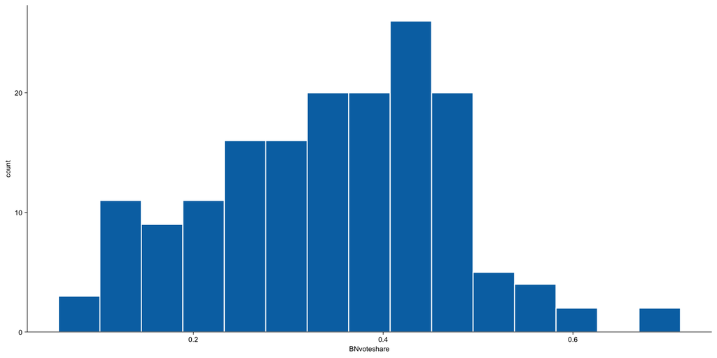

### Add title and axis labels

- Add title and axis labels using the `add_title()`, `adjust_x_axis_title()` and `adjust_y_axis_title()` functions.

```r
df.pen %>%
  tidyplot(x = BNvoteshare) %>%
  add_histogram(bins = 15, colour = "white") %>%
  add_title(title = "Histogram of BN vote share") %>%
  adjust_x_axis_title(title = "BN vote share") %>%
  adjust_y_axis_title(title = "Frequency")
```

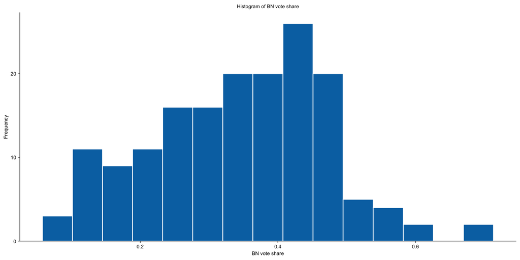

### Change fill colour of bars

- To change the fill colour of histogram bars, use the `adjust_colors()` function.

```r
df.pen %>%
  tidyplot(x = BNvoteshare) %>%
  add_histogram(bins = 15, colour = "white") %>%
  add_title(title = "Histogram of BN vote share") %>%
  adjust_x_axis_title(title = "BN vote share") %>%
  adjust_y_axis_title(title = "Frequency") %>%
  adjust_colors(new_colors = "darkgrey")
```

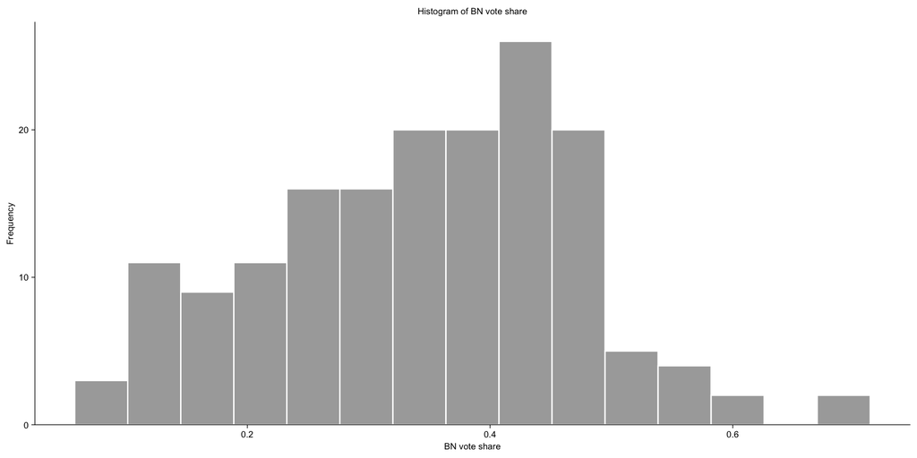

- To have `Urbanisation` factor reflected in the histogram.

```r
df.pen %>%
  tidyplot(x = BNvoteshare, fill = Urbanisation) %>%
  add_histogram(bins = 15, colour = "white") %>%
  add_title(title = "Histogram of BN vote share") %>%
  adjust_x_axis_title(title = "BN vote share") %>%
  adjust_y_axis_title(title = "Frequency")
```

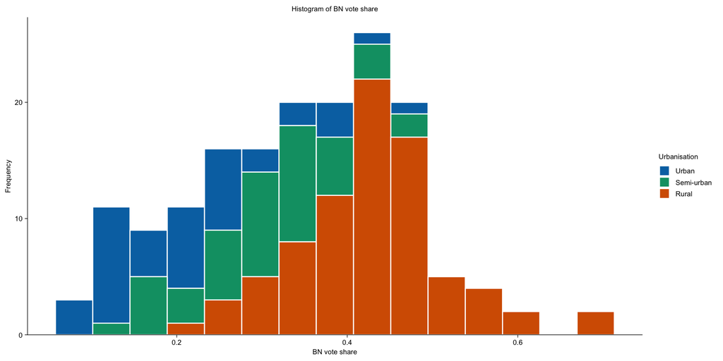

## 4.3 Bar Chart

### Bar chart for counts

- We’ll plot bar charts depicting the number of urban, semi-urban and rural seats using the `add_count_bar()` function. We’ll also label the number of seats in the chart using the `add_count_value()` function.

```r
df.pen %>%
  tidyplot(x = Urbanisation) %>%
  add_count_bar() %>%
  add_count_value()
```

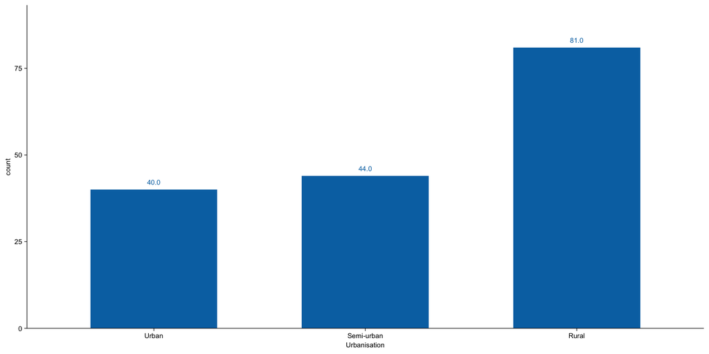

### Bar chart for proportions

- There is no `tidyplot` function that directly plots the proportions.
- Hence, to plot the proportions, we’ll have to first create a proportion variable, `prop`, calculated via the `count` and `mutate` functions before piping it (i.e. `prop`) into the `tidyplot` function with `add_mean_bar()`.

```r
df.pen %>%
  count(Urbanisation) %>%
  mutate(prop = n/sum(n)) %>%
  tidyplot(y = prop, x = Urbanisation) %>%
  add_mean_bar()
```

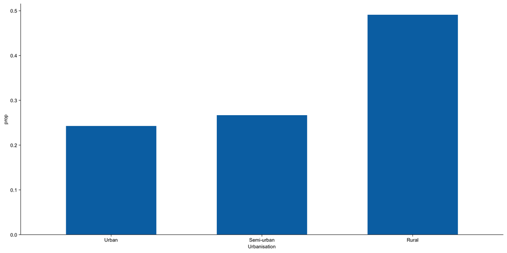

- We can easily add the proportion labels with the `add_mean_value()` function.

```r
df.pen %>%
  count(Urbanisation) %>%
  mutate(prop = n/sum(n)) %>%
  tidyplot(y = prop, x = Urbanisation) %>%
  add_mean_bar() %>%
  add_mean_value(accuracy = 0.01)
```

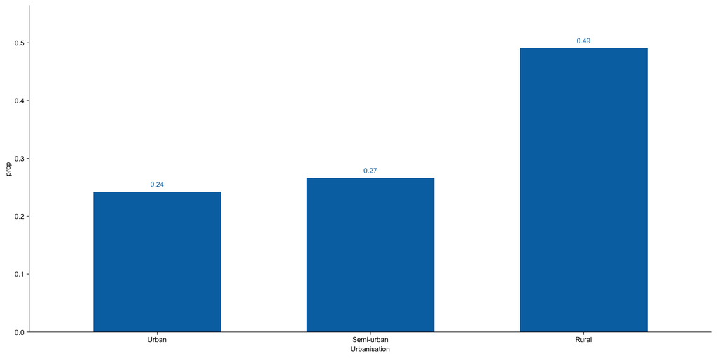

- In this case, the `ggplot` function would probably be more effective and efficient as it does not require the explicit calculation of the proportions. We would just use `after_stat(prop)` that does the calculation for us under the hood. However, the `tidyplot` function provides an easier option for providing the labels.

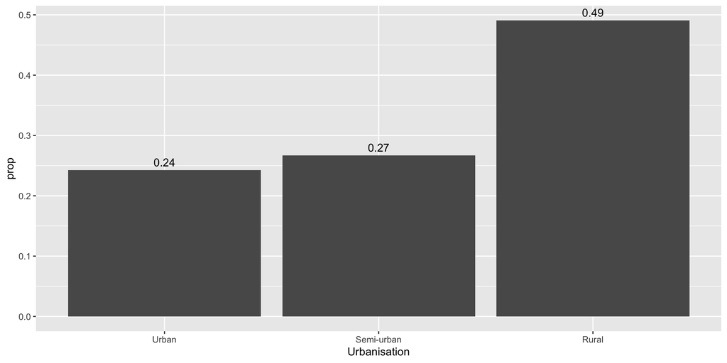

```r
library(ggstats) #for the after_stat(prop) function

df.pen %>%
  ggplot(aes(x = Urbanisation,
             y = after_stat(prop),
             group = 1)) +
  geom_bar() +
  geom_text(aes(label = round(after_stat(prop),2)),
            stat = "prop",
            vjust = -.5)
```

- To plot the proportion of Urbanisation seats per state, we use the `add_barstack_relative()` function:

```r
df.pen %>%
  tidyplot(x = State, fill = Urbanisation) %>%
  add_barstack_relative() %>%
  adjust_x_axis(rotate_labels = 90) %>%
  adjust_y_axis_title(title = "Percentage") +
  geom_prop_text(size = 2) +
  scale_y_continuous(labels = scales::percent)
```

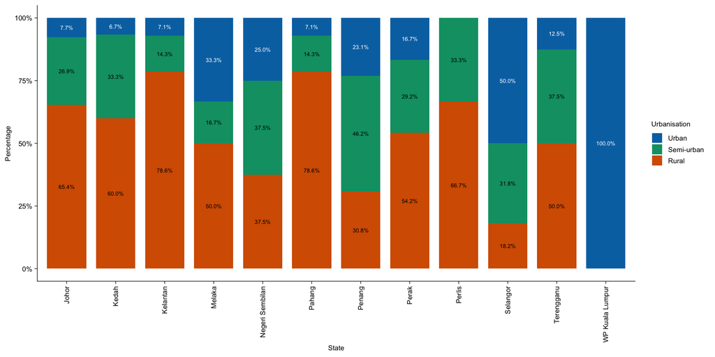

- Note that we’ve used the `geom_prop_text()` function from the `ggstats` package for easy labelling. Hence, as per the function’s use, we use the `+` operator instead of the `%>%` operator. Same goes with the `scale_y_continuous()` function to have the y-axis labels in percentage.
- The equivalent in `ggplot()` would be:

```r
ggplot(df.pen, aes(x = State, fill = Urbanisation, by = factor(State))) +
  geom_bar(position = "fill") +
  geom_text(aes(label = scales::percent(after_stat(prop),accuracy = .1)),
            stat = "prop",
            position = position_fill(.5),
            size = 3) +
  scale_fill_brewer(palette = 1) +
  scale_y_continuous(labels = scales::percent) +
  theme(axis.text.x = element_text(angle = 90, hjust = 1)) +
  labs(y = "Proportion")
```

## 4.4 Boxplot

- Boxplots are used to display the minimum, maximum, 1st quartile, median and 3rd quartile values of a continuous variable.
- Most useful when comparing these values across categories of a qualitative variable.
- To view the support for BN across the states,

```r
df.pen %>%
  tidyplot(x = State, y = BNvoteshare) %>%
  add_boxplot()
```

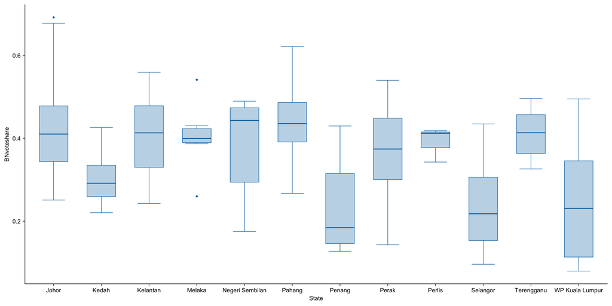

- To add the data points in the boxplot, use the `add_data_points()` or `add_data_points_jitter()` function. Use the `alpha` argument to control the opacity of the data points.

```r
df.pen %>%
  tidyplot(x = State, y = BNvoteshare) %>%
  add_boxplot() %>%
  add_data_points_jitter(alpha = 0.5)
```

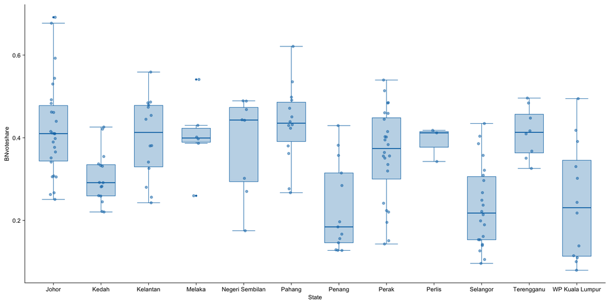

- Recall the use of the following functions:
  - `add_title(title = ...)`
  - `adjust_x_axis_title(title = ...)`
  - `adjust_y_axis_title(title = ...)`
  - `adjust_x_axis(rotate_labels = 90`) to rotate the x-axis tick labels.
- We can also have statistical test results displayed using `add_test_pvalue`, and `add_test_asterisks` to denote statistical significance.

```r
df.pen %>%
  tidyplot(x = Winner, y = BNvoteshare) %>%
  add_boxplot() %>%
  add_test_pvalue(p.adjust.method = "bonferroni") %>%
  add_test_asterisks()
```

[figure not shown]